# Additional Material for Correlation and Regression Chapters

Additional material for the chapters ‘Correlation’ and ‘Regression’ from Breakwell, et al (2025) Research Methods in Psychology

Authors

Affiliations

Jeremy Miles

University of Southern California, Los Angeles

Google, Los Angeles, USA

Mark Shevlin

University of Ulster, N Ireland, UK

Published

March 2, 2025

*This document contains links to data, and all of the code to reproduce the examples found in the chapters on Correlation and Regression in Breakwell, et al (2025), Research Methods in Psychology, published by Sage.*

*This page is written using [Quarto](https://notebooklm.google.com/notebook/1efedbc4-8bc9-4dc2-af1c-466bd097e424/audio), a scientific publishing system that lets you link data and code to produce a document. This document, and the source code that can be used to create this document can be found at https://github.com/jeremymiles/rmip. You will need either [RStudio](https://posit.co/download/rstudio-desktop/) or [Positron](https://positron.posit.co/), both of which are free to download, to compile this document.*

*This document has a [GPL 3.0](https://www.gnu.org/licenses/gpl-3.0.en.html) licence. That means you are free to share, adapt or modify the document, but you also need to share the source code ([the quarto markdown document](https://github.com/jeremymiles/rmip/blob/main/correlation_and_regression.qmd)) for free if you do that.*

*You can find the original version of this document at: https://jeremymiles.github.io/rmip/correlation_and_regression.html*

# *(Sort of) Podcasts*

*We have used [NotebookLM](https://notebooklm.google.com/) to create two podcasts that cover the material in each chapter. They are generated by AI, and they are not perfect, they add some information that is not in the chapters, but we think do quite a good job of covering the material in the chapters.*

- [*Link to correlation ‘podcast’*](https://notebooklm.google.com/notebook/1efedbc4-8bc9-4dc2-af1c-466bd097e424/audio) *(~26 minutes)*
- [*Link to regression ‘podcast’*](https://notebooklm.google.com/notebook/c7730339-2a09-417e-a0d2-922b3a9c9cd9/audio) *(~37 minutes)

# *Correlation*

## *The Code*

*First we need to load the packages that we’re going to be using in the document. If you don’t have these installed in your R environment, you need to add them, which you almost certainly do by running:*

*`install.packages("package_name")`*

*Note that in the code below, we’ve used `output=FALSE` in this code block We did that so that the document isn’t full of messages about each package. If you run into problems, change that to `TRUE` and you might get a helpful error message.*

```r
library(boot.pval)
library(car)
library(datasauRus)
library(datasets)
library(dplyr)
library(ggplot2)
library(haven)
library(lmtest)
library(lubridate)
library(MASS)
library(NHANES)
library(QuantPsyc)
library(sandwich)
library(stringr)
library(tidyr)
```

### *Galton*

*First we’ll load the Galton data. The data are loaded straight from github, so we assume that you have an internet connection to do this.*

```r
d_galton <-
  read.table(
    paste0("https://raw.githubusercontent.com/jeremymiles/",
           "rmip/refs/heads/main/Galton.dat"),
    header = TRUE)

head(d_galton)
```

```
  family father mother gender height kids
1      1   78.5   67.0      M   73.2    4
2      1   78.5   67.0      F   69.2    4
3      1   78.5   67.0      F   69.0    4
4      1   78.5   67.0      F   69.0    4
5      2   75.5   66.5      M   73.5    4
6      2   75.5   66.5      M   72.5    4
```

*We only want to look at the boys, so we will filter the data to include them, and then we can produce the plot in Figure 1.*

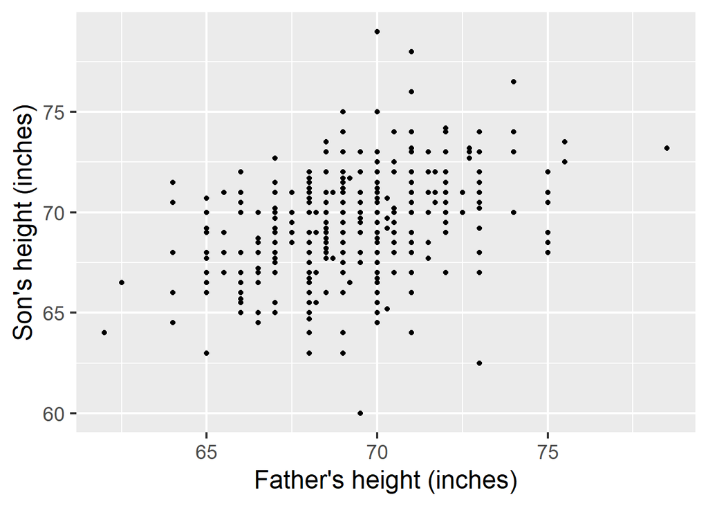

Figure 1: Scatter plot of heights of fathers and sons from Galton’s data.

```r
d_male <- d_galton %>%
  dplyr::filter(gender == "M")

# Figure 1
ggplot2::ggplot(d_male, aes(x = father, y = height)) +
  geom_point() +
  ylab("Son's height (inches)") +
  xlab("Father's height (inches)") +
  theme_gray(base_size = 18)
```

*We can calculate the correlation in this data.*

```r
cor(d_male$father, d_male$height)
```

```
[1] 0.3913174
```

## *Representing Scatterplots*

*Some code to set up the data for the scatterplots.*

```r
GenerateCorrelatedNormals <- function(n, mean_x = 0, sd_x = 1, mean_y = 0, sd_y = 1, r) {
  z_temp <- scale(rnorm(n))
  z2 <- scale(resid(lm(z_temp ~ z1)))

  # Generate correlated standard normal variables
  x_std <- z1
  y_std <- r * z1 + sqrt(1 - r^2) * z2
  # Scale and shift to desired means and standard deviations

  y <- scale(mean_y + sd_y * y_std)

  return(y)
}
# setting the seed ensures consistent results
set.seed(42)
n <- 100  # Number of observations
r <- -0.5   # Desired correlation
z1 <- scale(rnorm(n))

d <- data.frame(
  x = z1) %>%
  dplyr::mutate(
    `y: r = 1.00` = GenerateCorrelatedNormals(n, r = 1),
    `y: r = 0.90` = GenerateCorrelatedNormals(n, r = 0.9),
    `y: r = 0.50` = GenerateCorrelatedNormals(n, r = 0.5),
    `y: r = 0.30` = GenerateCorrelatedNormals(n, r = 0.3),
    `y: r = 0.10` = GenerateCorrelatedNormals(n, r = 0.1),
    `y: r = 0.00` = GenerateCorrelatedNormals(n, r = 0.0),
    `y: r = -0.20` = GenerateCorrelatedNormals(n, r = -0.2),
    `y: r = -0.50` = GenerateCorrelatedNormals(n, r = -0.5)
  )
```

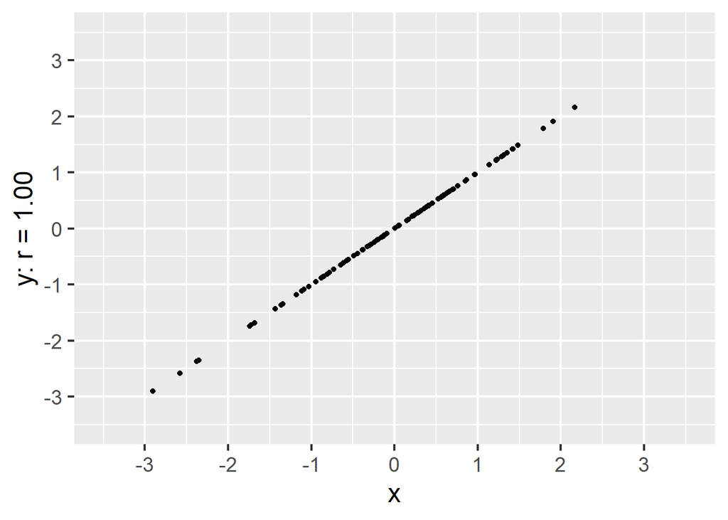

Figure 2: *r* = 1.00 All the points are in a straight line.

```r
ggplot2::ggplot(d, aes(x = x, y = `y: r = 1.00`)) +
  geom_point() +
  scale_x_continuous(
    limits = c(-3.5, 3.5), # Sets the axis limits
    breaks = seq(-3, 3, by = 1) # Sets the tick mark locations
  ) +
  scale_y_continuous(
    limits = c(-3.5, 3.5), # Sets the axis limits
    breaks = seq(-3, 3, by = 1) # Sets the tick mark locations
  ) +
  theme_gray(base_size = 18)
```

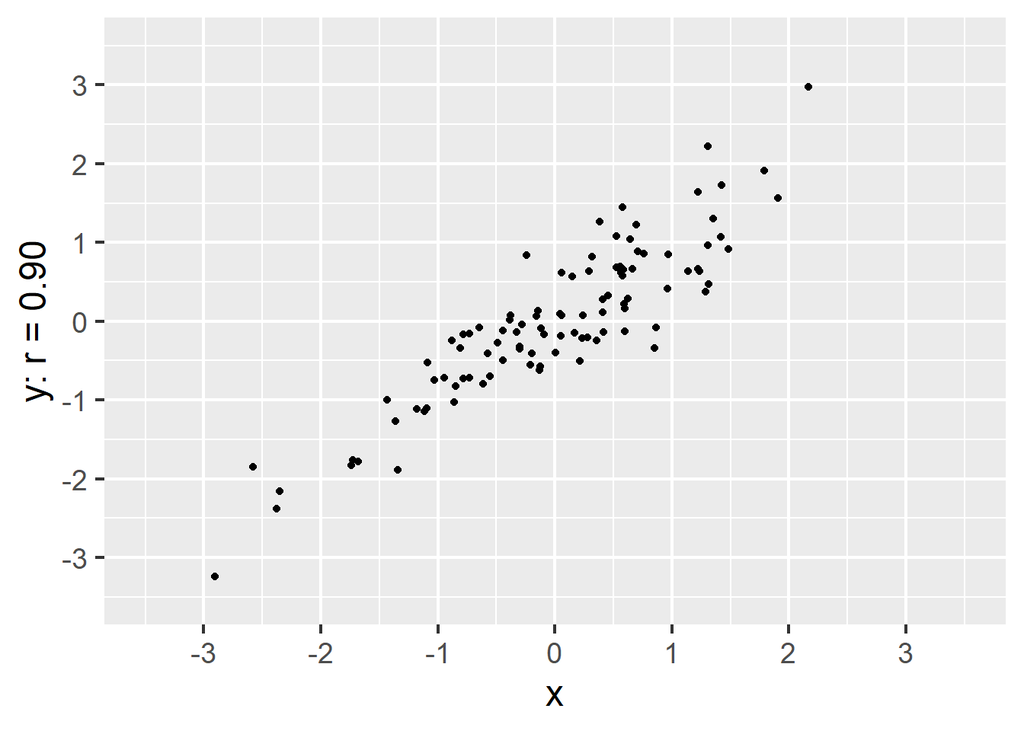

Figure 3: *r* = .90 the points are close to the diagonal line, but definitely do not lie on the line.

```r
ggplot2::ggplot(d, aes(x = x, y = `y: r = 0.90`)) +
  geom_point() +
  scale_x_continuous(
    limits = c(-3.5, 3.5), # Sets the axis limits
    breaks = seq(-3, 3, by = 1) # Sets the tick mark locations
  ) +
  scale_y_continuous(
    limits = c(-3.5, 3.5), # Sets the axis limits
    breaks = seq(-3, 3, by = 1) # Sets the tick mark locations
  ) +
  theme_gray(base_size = 18)
```

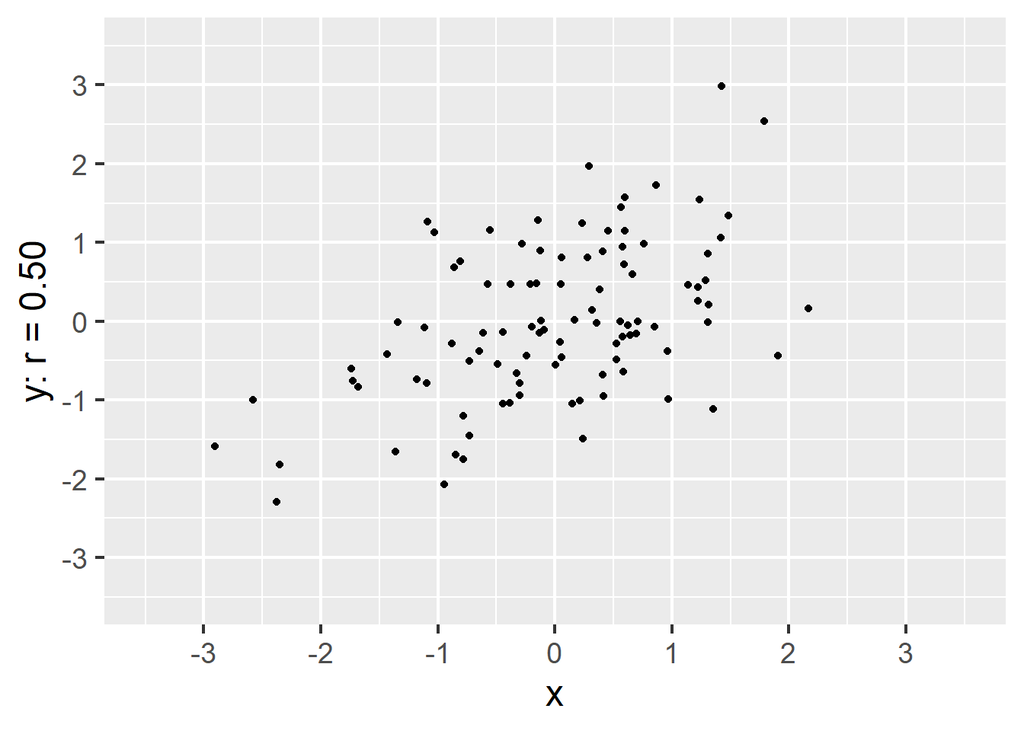

Figure 4: *r* = .50. It’s still clear that there’s a positive relationship, but it is not *as* clear.

```r
ggplot2::ggplot(d, aes(x = x, y = `y: r = 0.50`)) +
  geom_point() +
  scale_x_continuous(
    limits = c(-3.5, 3.5), # Sets the axis limits
    breaks = seq(-3, 3, by = 1) # Sets the tick mark locations
  ) +
  scale_y_continuous(
    limits = c(-3.5, 3.5), # Sets the axis limits
    breaks = seq(-3, 3, by = 1) # Sets the tick mark locations
  ) +
  theme_gray(base_size = 18)
```

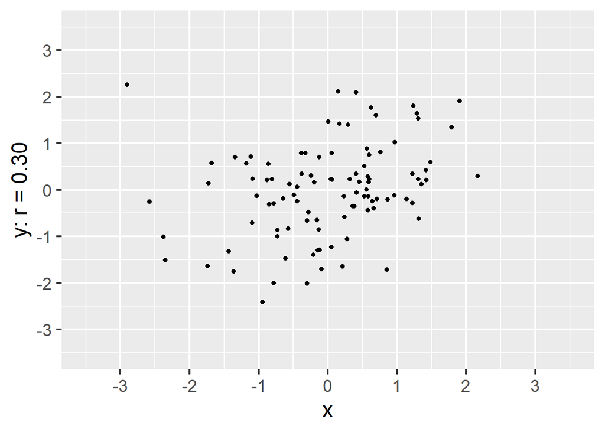

Figure 5: *r* = 0.30. It’s now less clear that there is a positive relationship.

```r
ggplot2::ggplot(d, aes(x = x, y = `y: r = 0.30`)) +
  geom_point() +
  scale_x_continuous(
    limits = c(-3.5, 3.5), # Sets the axis limits
    breaks = seq(-3, 3, by = 1) # Sets the tick mark locations
  ) +
  scale_y_continuous(
    limits = c(-3.5, 3.5), # Sets the axis limits
    breaks = seq(-3, 3, by = 1) # Sets the tick mark locations
  ) +
  theme_gray(base_size = 18)
```

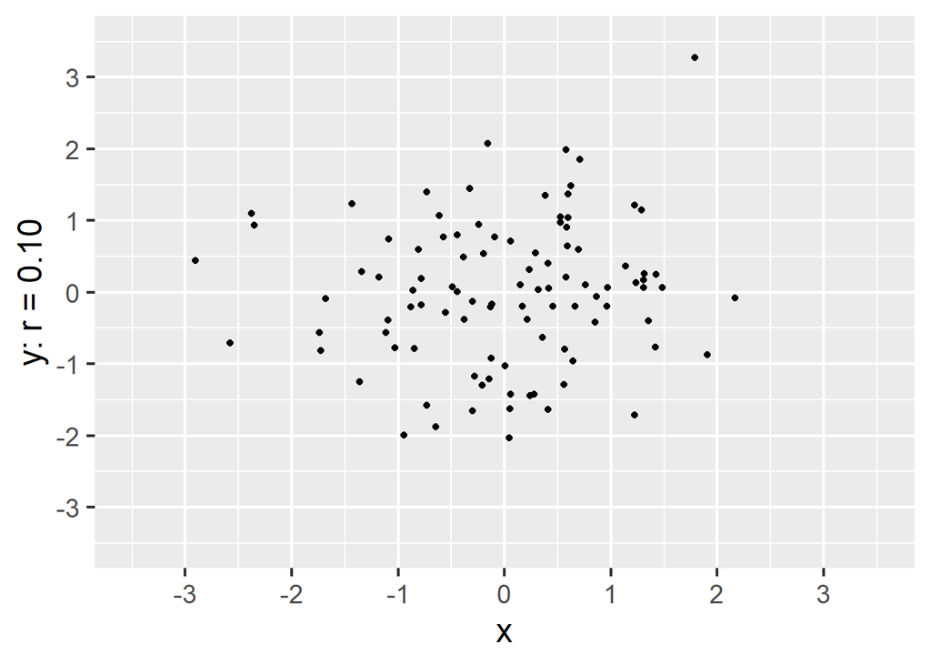

Figure 6: *r* = .10. We don’t think that it’s possible to tell the difference between a relationship of .1 and of zero by looking at the plot.

```r
ggplot2::ggplot(d, aes(x = x, y = `y: r = 0.10`)) +
  geom_point() +
  scale_x_continuous(
    limits = c(-3.5, 3.5), # Sets the axis limits
    breaks = seq(-3, 3, by = 1) # Sets the tick mark locations
  ) +
  scale_y_continuous(
    limits = c(-3.5, 3.5), # Sets the axis limits
    breaks = seq(-3, 3, by = 1) # Sets the tick mark locations
  ) +
  theme_gray(base_size = 18)
```

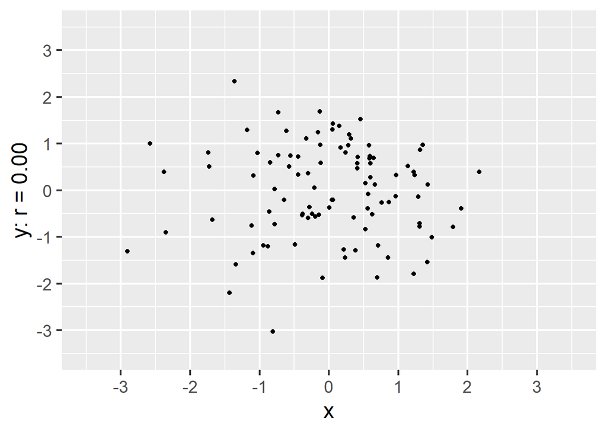

Figure 7: *r* = 0.00. We don’t think that it’s possible to tell the difference between a relationship of .1 and of zero by looking at the plot.

```r
ggplot2::ggplot(d, aes(x = x, y = `y: r = 0.00`)) +
  geom_point() +
  scale_x_continuous(
    limits = c(-3.5, 3.5), # Sets the axis limits
    breaks = seq(-3, 3, by = 1) # Sets the tick mark locations
  ) +
  scale_y_continuous(
    limits = c(-3.5, 3.5), # Sets the axis limits
    breaks = seq(-3, 3, by = 1) # Sets the tick mark locations
  ) +
  theme_gray(base_size = 18)
```

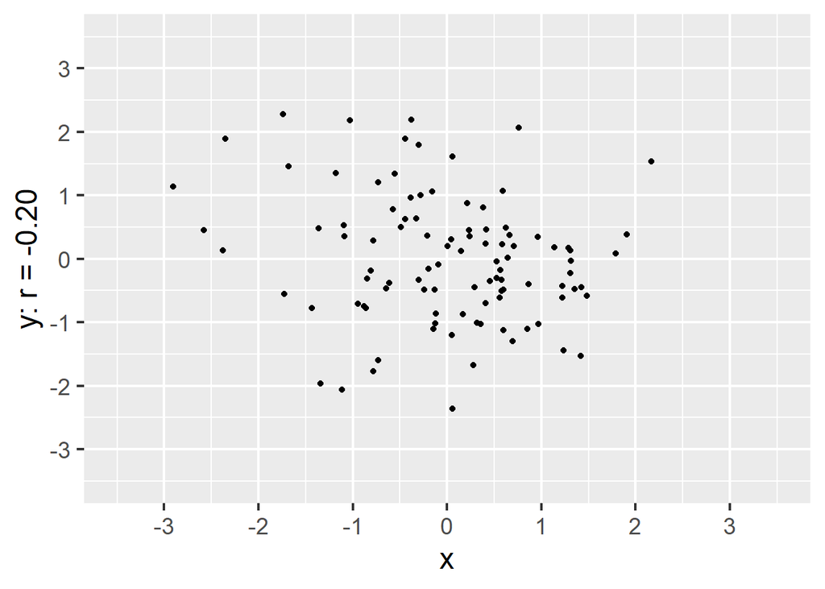

Figure 8: *r* = -.20 A small negative relationship - not easy to see.

```r
ggplot2::ggplot(d, aes(x = x, y = `y: r = -0.20`)) +
  geom_point() +
  scale_x_continuous(
    limits = c(-3.5, 3.5), # Sets the axis limits
    breaks = seq(-3, 3, by = 1) # Sets the tick mark locations
  ) +
  scale_y_continuous(
    limits = c(-3.5, 3.5), # Sets the axis limits
    breaks = seq(-3, 3, by = 1) # Sets the tick mark locations
  ) +
  theme_gray(base_size = 18)
```

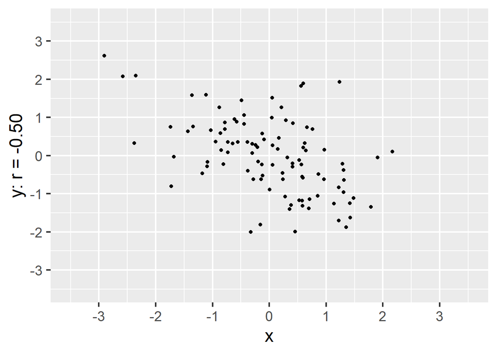

Figure 9: *r* = -.50 this clearly shows a negative relationship - higher values of x are associated with lower values of y..

```r
ggplot2::ggplot(d, aes(x = x, y = `y: r = -0.50`)) +
  geom_point() +
  scale_x_continuous(
    limits = c(-3.5, 3.5), # Sets the axis limits
    breaks = seq(-3, 3, by = 1) # Sets the tick mark locations
  ) +
  scale_y_continuous(
    limits = c(-3.5, 3.5), # Sets the axis limits
    breaks = seq(-3, 3, by = 1) # Sets the tick mark locations
  ) +
  theme_gray(base_size = 18)
```

## *Correlation Formula*

*Most people aren’t very interested in this part. If you’re doing calculating a correlation, you’re almost certainly doing it on a computer, so the formula isn’t very enlightening. We didn’t bother putting it into the chapter, so we’re adding it here instead.*

*(Needs expanding)*

$$r_{xy} = \frac{\sum_{i=1}^{n} (x_i - \bar{x})(y_i - \bar{y})}{\sqrt{\sum_{i=1}^{n} (x_i - \bar{x})^2} \sqrt{\sum_{i=1}^{n} (y_i - \bar{y})^2}}$$

## *Correlation Assumptions*

### *Linearity*

#### *Yerkes-Dodson*

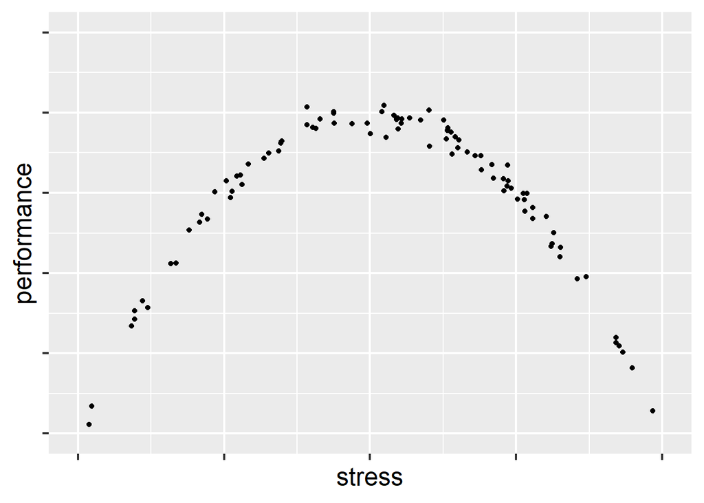

Figure 10: The Yerkes-Dodson law of arousal and performance. The graph shows that the two variables are related, but the correlation is *r* = -0.01.

```r
d <- data.frame(stress = rnorm(100)) %>%
  dplyr::mutate(performance = -(stress^2) + rnorm(100) * 0.1) %>%
  dplyr::filter(performance > -4)
ggplot2::ggplot(
  d, aes(x = stress, y = performance)
) +
  geom_point() +
  scale_x_continuous(
    limits = c(-2, 2), # Sets the axis limits
    breaks = seq(-2, 2, by = 1) # Sets the tick mark locations
  ) +
  scale_y_continuous(
    limits = c(-4, 1), # Sets the axis limits
    breaks = seq(-4, 1, by = 1) # Sets the tick mark locations,

  ) +
  theme_gray(
    base_size = 18
  ) +
  theme(
    axis.text.x = element_blank(),
    axis.text = element_blank()
  )

yd_cor <- cor(d)[1, 2]
```

*The correlation between stress and performance is -0.01.*

#### *NHANES age and Height*

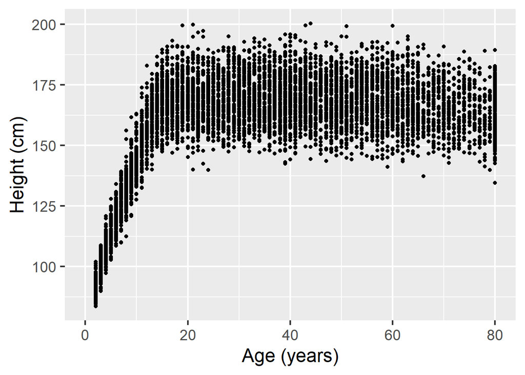

Figure 11: Relationship between height and age from the NHANES dataset

```r
data(NHANES)
cor_all <-  NHANES %>%
  dplyr::select(Age, Height) %>%
  cor(use = "pair")

ggplot2::ggplot(NHANES, aes(x = Age, y = Height)) +
  geom_point() +
  theme_gray(base_size = 18)+
  ylab("Height (cm)") +
  xlab("Age (years)")

cor_0_18 <- NHANES %>%
  dplyr::select(Age, Height) %>%
  dplyr::filter(Age <= 18) %>%
  cor(use = "pair")

cor_19_plus <- NHANES %>%
  dplyr::select(Age, Height) %>%
  dplyr::filter(Age > 18) %>%
  cor(use = "pair")
```

*For all groups combined, correlation between age and height is* *r* *= 0.46. For people aged up to 18, the correlation is* *r* *= 0.94, and for those over 18,* *r* *= -0.16.*

### Outliers

#### Monarchs

*Read in the monarchs data.*

```r
monarchs <- read.csv("https://raw.githubusercontent.com/jeremymiles/rmip/refs/heads/main/monarchs.csv")

# convert birth variable to date format, deal with William and Mary,
# and create gender variable.

monarchs <- monarchs %>%
  dplyr::mutate(
    birth = as.Date(birth),
    years =  as.numeric(gsub(",", "", days)) / 365.25,
    name = ifelse(
      name == "King William III and Queen Mary II",
      "King William III",
      name),
    gender =
      ifelse(stringr::str_detect(name, "Queen"), "Queen", "King")
  )

head(monarchs)
```

```
                           name      birth   days                       age
1  King William I The Conqueror 1028-09-01 21,557           59 years 7 days
2         King William II Rufus 1056-06-01 16,132  44 years 2 months 0 days
3                  King Henry I 1068-09-01 24,562 67 years 2 months 29 days
4                  King Stephen 1097-06-01 20,964 57 years 4 months 23 days
5                 King Henry II 1133-03-05 20,577  56 years 4 months 1 days
6 King Richard I The Lion Heart 1157-09-08 15,185 41 years 6 months 27 days
     years gender
1 59.01985   King
2 44.16701   King
3 67.24709   King
4 57.39630   King
5 56.33676   King
6 41.57426   King
```

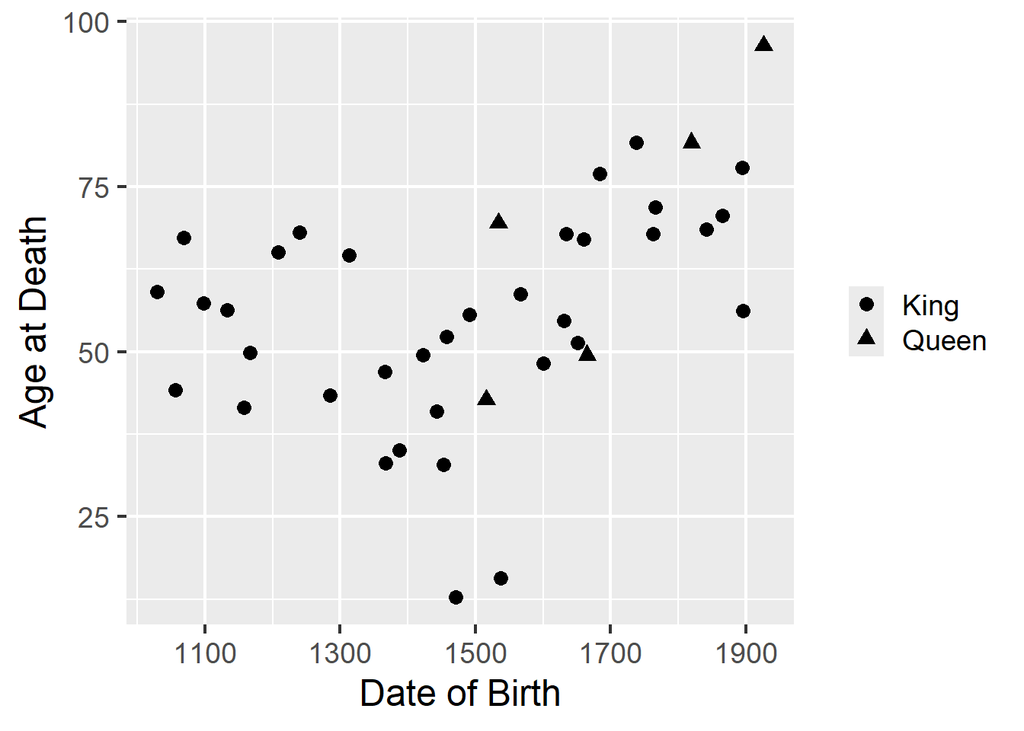

Figure 12: Dates of birth and ages at death for British monarchs since William I. Kings are indicated with circles, queens with triangles.

```r
ggplot2::ggplot(
  monarchs, aes(x = birth, y = years, shape = gender)
) +
  geom_point(size = 3) +
  theme_gray(base_size = 18) +
  xlab("Date of Birth") +
  ylab("Age at Death") +
  labs(shape = NULL)
```

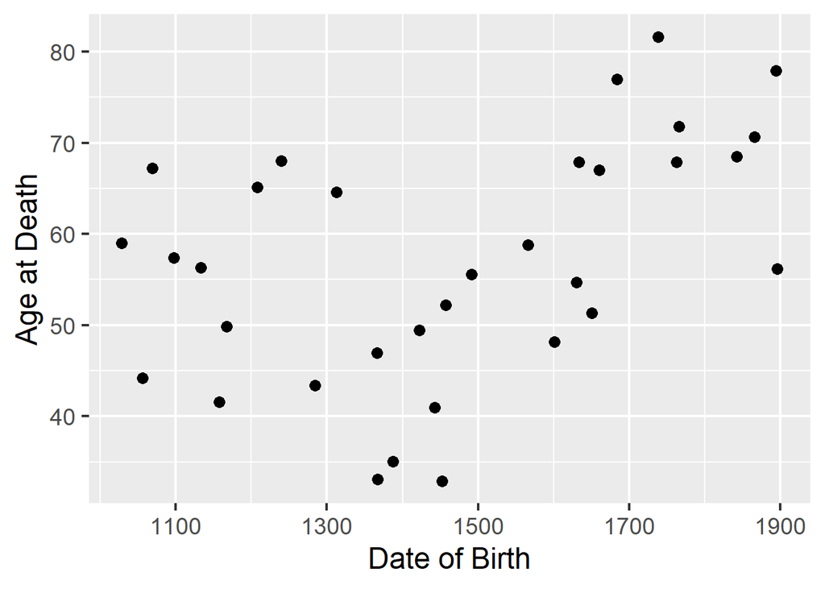

```r
monarch_cor_all <- monarchs %>%
  dplyr::mutate(
    birth = as.numeric(birth)
  ) %>%
  dplyr::select(birth, years) %>%
  cor()


monarchs_cor_no_elizabeth <- monarchs %>%
  dplyr::filter(name != "Queen Elizabeth II"
) %>%
  dplyr::mutate(
    birth = as.numeric(birth)
  ) %>%
  dplyr::select(birth, years) %>%
  cor()


monarchs_cor_no_queens <- monarchs %>%
    dplyr::filter(!stringr::str_detect(name, "Queen")
  ) %>%
  dplyr::mutate(
    birth = as.numeric(birth)
  ) %>%
  dplyr::select(birth, years) %>%
  cor()


kings_reigned <- monarchs %>%
    dplyr::filter(!stringr::str_detect(name, "Queen")
  ) %>%
  dplyr::filter(years > 20)

ggplot2::ggplot(
  kings_reigned, aes(x = birth, y = years)
) +
  geom_point(size = 3) +
  theme_gray(base_size = 18) +
  xlab("Date of Birth") +
  ylab("Age at Death")
```

```r
kings_cor_reigned <- kings_reigned %>%
  dplyr::mutate(
    birth = as.numeric(birth)
  ) %>%
  dplyr::select(birth, years) %>%
  cor()
```

| Data | Correlation |
| --- | --- |
| All Monarchs | 0.41 |
| No Elizabeth II | 0.34 |
| Kings Only | 0.32 |
| Kings who Reigned Only | 0.43 |

#### Anscombe

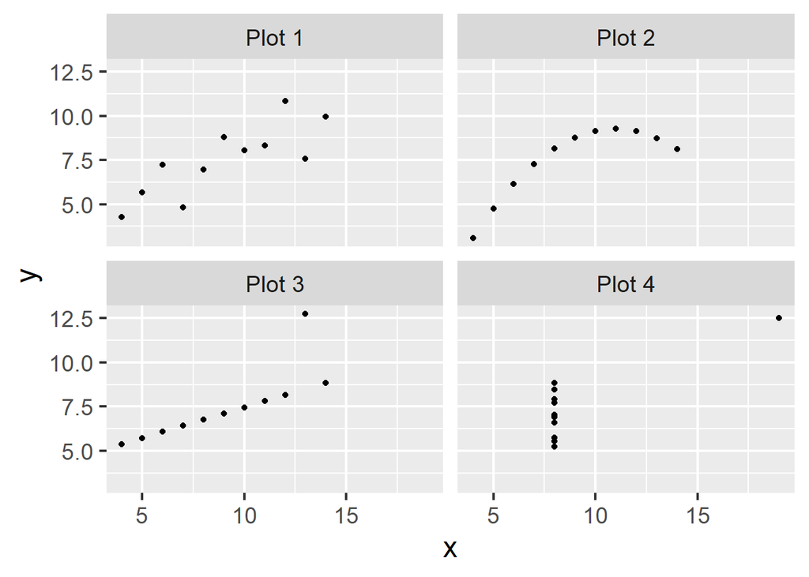

Figure 13: The Anscombe Quartet.

```r
data(anscombe)

# To use ggplot facets we need data in long format
long_data <- anscombe %>%
  dplyr::mutate(id = row_number()) %>%
  tidyr::pivot_longer(
    cols = c(x1, x2, x3, x4, y1, y2, y3, y4),
    names_to = "variable",
    values_to = "value"
  ) %>%
  tidyr::separate(
    variable,
    into = c("type", "number"),
    sep = 1 # Split at the first character
  ) %>%
  tidyr::pivot_wider(
    names_from = type,
    values_from = value
  ) %>%
  dplyr::mutate(plot = paste0("Plot ", number))

ggplot2::ggplot(
  long_data,
  aes(x = x, y = y)
  ) +
  geom_point() +
  facet_wrap(~ plot) +
  theme_gray(base_size = 18)
```

#### Datasaurus

The plots below show the datasaurus plots, and a table of means, standard deviations and correlations.

| dataset | mean_x | mean_y | sd_x | sd_y | cor |
| --- | --- | --- | --- | --- | --- |
| away | 54.27 | 47.83 | 16.77 | 26.94 | -0.06 |
| bullseye | 54.27 | 47.83 | 16.77 | 26.94 | -0.07 |
| circle | 54.27 | 47.84 | 16.76 | 26.93 | -0.07 |
| dino | 54.26 | 47.83 | 16.77 | 26.94 | -0.06 |
| dots | 54.26 | 47.84 | 16.77 | 26.93 | -0.06 |
| h_lines | 54.26 | 47.83 | 16.77 | 26.94 | -0.06 |
| high_lines | 54.27 | 47.84 | 16.77 | 26.94 | -0.07 |
| slant_down | 54.27 | 47.84 | 16.77 | 26.94 | -0.07 |
| slant_up | 54.27 | 47.83 | 16.77 | 26.94 | -0.07 |
| star | 54.27 | 47.84 | 16.77 | 26.93 | -0.06 |
| v_lines | 54.27 | 47.84 | 16.77 | 26.94 | -0.07 |
| wide_lines | 54.27 | 47.83 | 16.77 | 26.94 | -0.07 |
| x_shape | 54.26 | 47.84 | 16.77 | 26.93 | -0.07 |

Figure 14: The datasaurus examples.

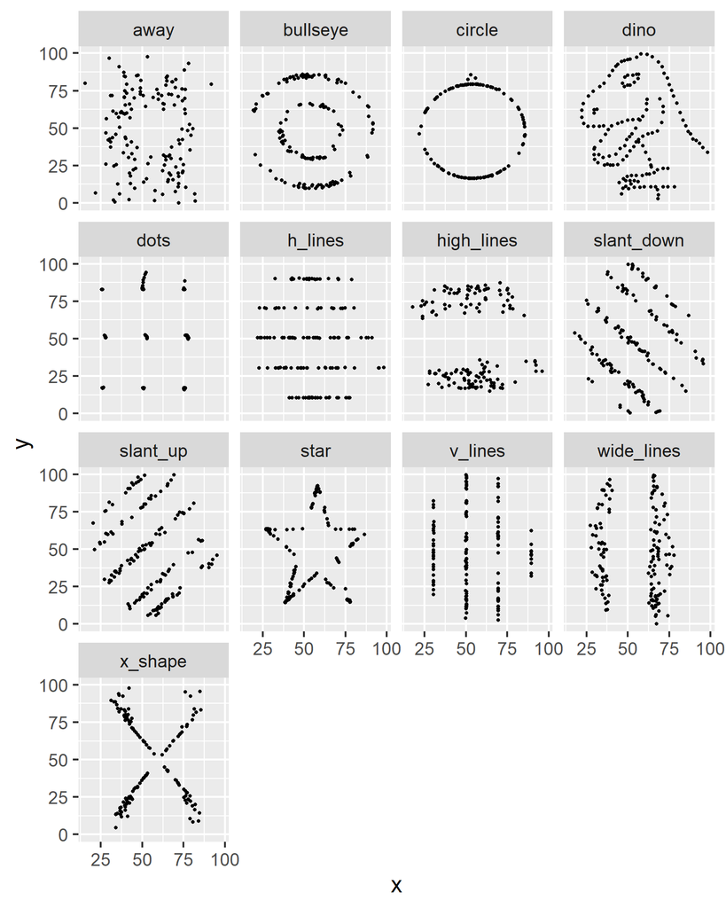

Figure 15: The datasaurus examples.

```r
data(datasaurus_dozen)

ggplot2::ggplot(
  datasaurus_dozen,
  aes(x = x, y = y)) +
  geom_point(size = 1) +
  theme_gray(base_size = 18) +
  facet_wrap(~dataset)

datasaurus_dozen %>%
  dplyr::group_by(dataset) %>%
  dplyr::summarise(
    mean_x = mean(x) %>% round(2),
    mean_y = mean(y) %>% round(2),
    sd_x = sd(x) %>% round(2),
    sd_y = sd(y) %>% round(2),
    cor = cor(x, y) %>% round(2)
  ) %>% knitr::kable()
```

### Normal Distribution

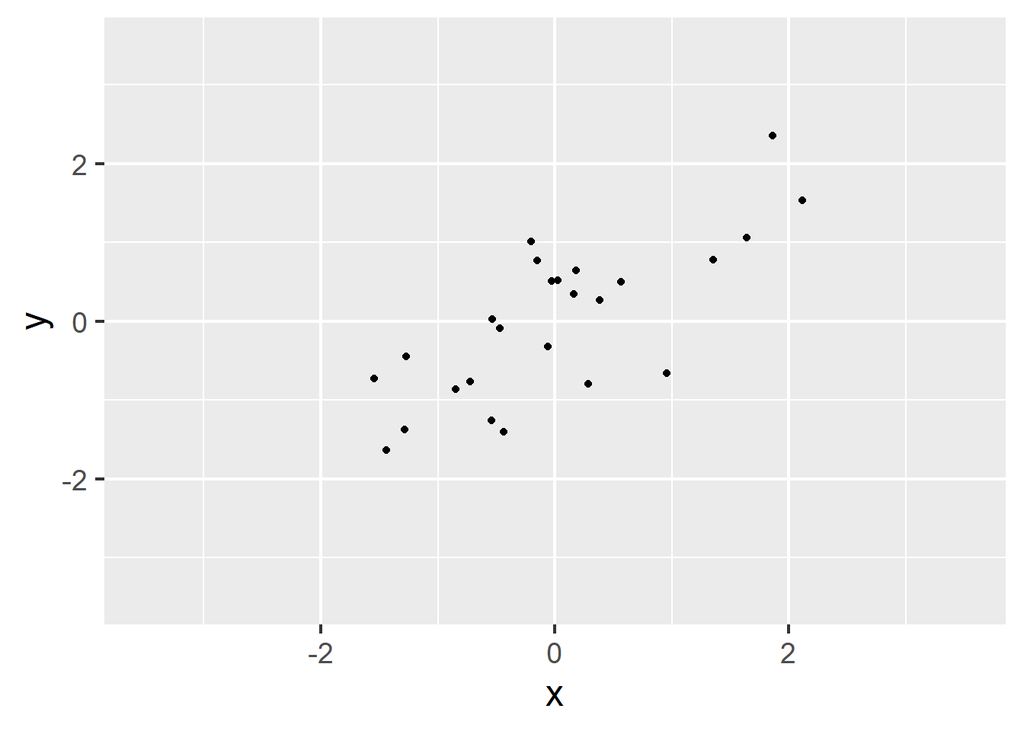

Figure 16: Figure 15a: Scatterplot showing bivariate normality.

```r
set.seed(42)
r <- 0.76
Sigma <- matrix(c(1, r, r, 1), nrow = 2)
d <- MASS::mvrnorm(n = 25, mu = c(0, 0), Sigma = Sigma, empirical = TRUE) %>%
  as.data.frame() %>%
  purrr::set_names(c("x", "y"))

ggplot2::ggplot(d, aes(x = x, y = y)) +
  geom_point() +
  xlim(c(-3.5, 3.5)) +
  ylim(c(-3.5, 3.5)) +
  theme_gray(base_size = 18)
```

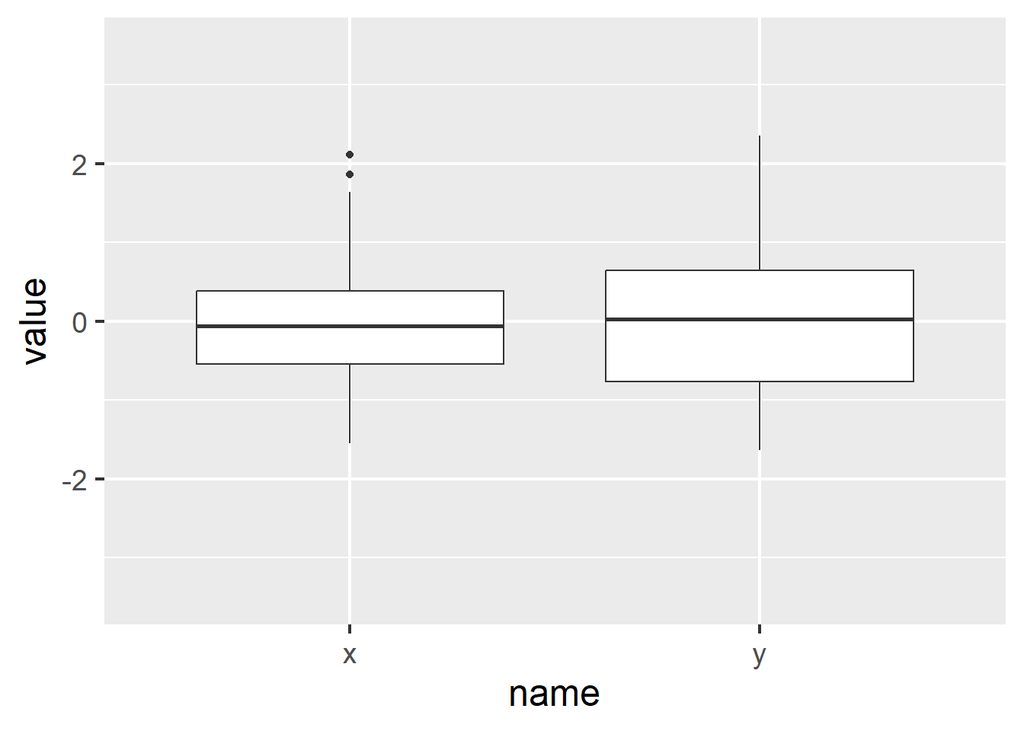

Figure 17: Boxplot showing that X and Y are both approximately normally distributed

```r
d_long <- d %>%
  tidyr::pivot_longer(
    cols = c("x", "y")
  )

d_long %>%
  ggplot2::ggplot(aes(x = name, y = value)) +
  geom_boxplot() +
  theme_gray(base_size = 18) +
  ylim(c(-3.5, 3.5))
```

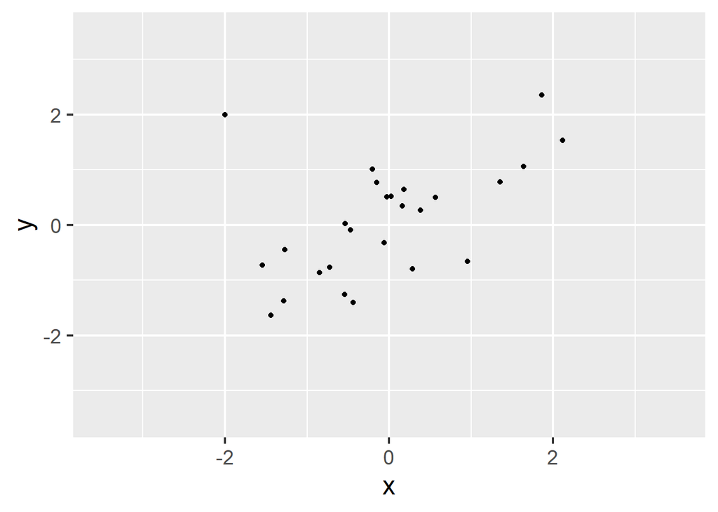

Figure 18: Scatterplot showing bivariate outlier

```r
d2 <- d %>%
  dplyr::bind_rows(data.frame(x = -2, y = 2))

ggplot2::ggplot(d2, aes(x = x, y = y)) +
  geom_point() +
  xlim(c(-3.5, 3.5)) +
  ylim(c(-3.5, 3.5)) +
  theme_gray(base_size = 18)
```

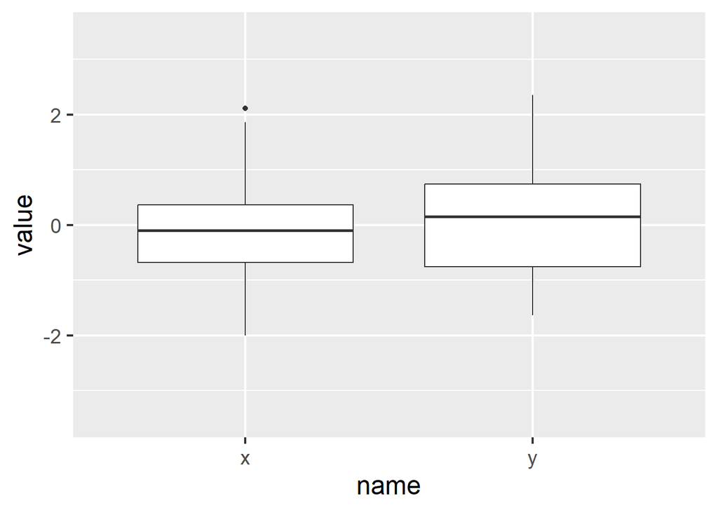

Figure 19: Boxplot showing that X and Y are both approximately normally distributed (even when there is a bivariate outlier)

```r
d2_long <- d2 %>%
  tidyr::pivot_longer(
    cols = c("x", "y")
  )

d2_long %>%
  ggplot2::ggplot(aes(x = name, y = value)) +
  geom_boxplot() +
  theme_gray(base_size = 18)  +
  ylim(c(-3.5, 3.5))
```